# 12 Playground – Interactions num num

```r
library(tidyverse)
library(interactions)  # for probe_interactions() plot
library(simglm)  # for simulating data

outdoors <- read_csv("../../data/salary2.csv", show_col_types = FALSE) |>
  rename(
    wellbeing = salary,
    outdoor_time = serv,
    hrs_sun = perf  # hrs sun in a day
  )

# palette_probe <- c('#4ab8fc', '#ff7b01')
```

# Plot data

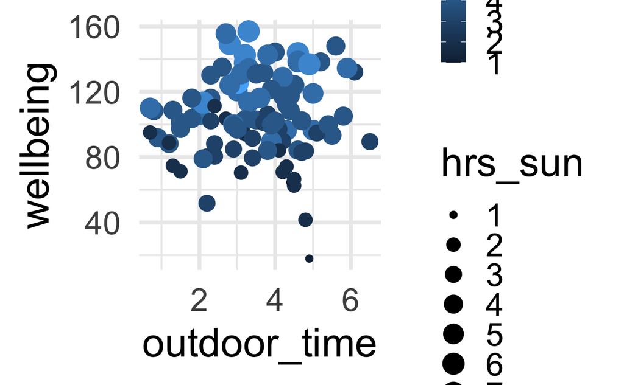

```r
outdoors |>
  mutate() |>
  ggplot(aes(x = outdoor_time, y = wellbeing, colour = hrs_sun, size = hrs_sun)) +
  geom_point()
```

## Facet by hrs_sun

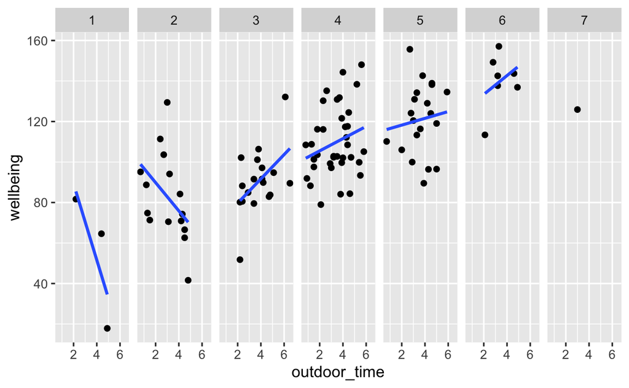

```r
outdoors |>
  mutate() |>
  ggplot(aes(x = outdoor_time, y = wellbeing)) +
  geom_point() +
  geom_smooth(method = 'lm', se = F) +
  facet_wrap(~ factor(hrs_sun), nrow=1)
```

Slopes over `outdoor_time` are different at different levels of `hrs_sun`. In particular, slopes over `outdoor_time` get more positive as `hrs_sun` gets larger.

Hard to plot the symmetrical interaction in the data, because we don’t have the plane yet that we slice to get each of the lines.

# Fit asis model

```r
m1 <- lm(wellbeing ~ outdoor_time * hrs_sun, data = outdoors)
summary(m1)
```

```
Call:
lm(formula = wellbeing ~ outdoor_time * hrs_sun, data = outdoors)

Residuals:
    Min      1Q  Median      3Q     Max
-43.008  -9.710  -1.068   8.674  48.494

Coefficients:
                     Estimate Std. Error t value Pr(>|t|)
(Intercept)            87.920     16.376   5.369 5.51e-07 ***
outdoor_time          -10.944      4.538  -2.412  0.01779 *
hrs_sun                 3.154      4.311   0.732  0.46614
outdoor_time:hrs_sun    3.255      1.193   2.728  0.00758 **
---
Signif. codes:  0 ‘***’ 0.001 ‘**’ 0.01 ‘*’ 0.05 ‘.’ 0.1 ‘ ’ 1

Residual standard error: 17.55 on 96 degrees of freedom
Multiple R-squared:  0.5404,    Adjusted R-squared:  0.5261
F-statistic: 37.63 on 3 and 96 DF,  p-value: 3.631e-16
```

```r
m1_probe <- probe_interaction(
  m1,
  pred = outdoor_time,
  modx = hrs_sun,
  cond.int = T,
  interval = T,
  jnplot = T
)
```

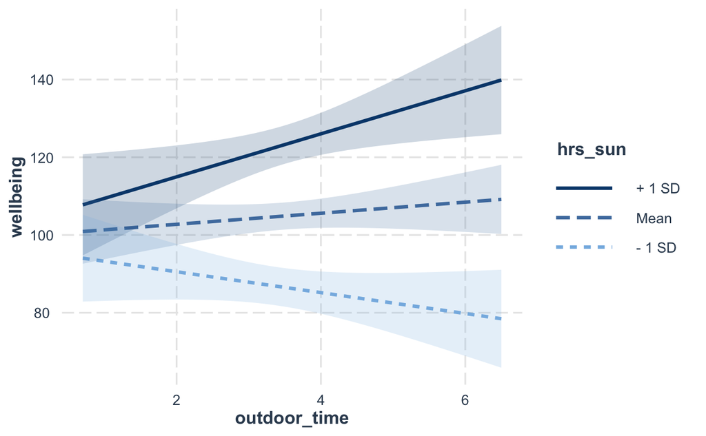

```r
m1_probe$interactplot
```

## Simple slopes sig test

Gives both a pretty-printed simple slopes analysis and the johnson-neyman plot.

```
JOHNSON-NEYMAN INTERVAL

When hrs_sun is OUTSIDE the interval [1.79, 4.33], the slope of outdoor_time is p < .05.

Note: The range of observed values of hrs_sun is [1.00, 7.00]

SIMPLE SLOPES ANALYSIS

When hrs_sun = 2.536687 (- 1 SD):

                               Est.   S.E.   t val.      p
--------------------------- ------- ------ -------- ------
Slope of outdoor_time         -2.69   1.88    -1.43   0.16
Conditional intercept         95.92   6.83    14.04   0.00

When hrs_sun = 3.800000 (Mean):

                               Est.   S.E.   t val.      p
--------------------------- ------- ------ -------- ------
Slope of outdoor_time          1.42   1.36     1.04   0.30
Conditional intercept         99.90   5.06    19.75   0.00

When hrs_sun = 5.063313 (+ 1 SD):

                                Est.   S.E.   t val.      p
--------------------------- -------- ------ -------- ------
Slope of outdoor_time           5.54   2.18     2.54   0.01
Conditional intercept         103.89   7.99    13.01   0.00
```

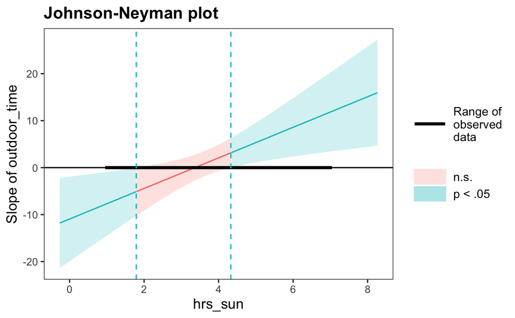

```r
m1_probe$simslopes
```

```r
m1_probe$simslopes$slopes
```

| Value of hrs_sun | Est. | S.E. | 2.5% | 97.5% | t val. | p |
| --- | --- | --- | --- | --- | --- | --- |
| 2.536687 | -2.687136 | 1.877723 | -6.414387 | 1.040114 | -1.431061 | 0.15565998 |
| 3.800000 | 1.424880 | 1.364229 | -1.283094 | 4.132854 | 1.044458 | 0.29889653 |
| 5.063313 | 5.536896 | 2.177515 | 1.214564 | 9.859229 | 2.542760 | 0.01259677 |

^ sig test is whether slope is diff from 0.

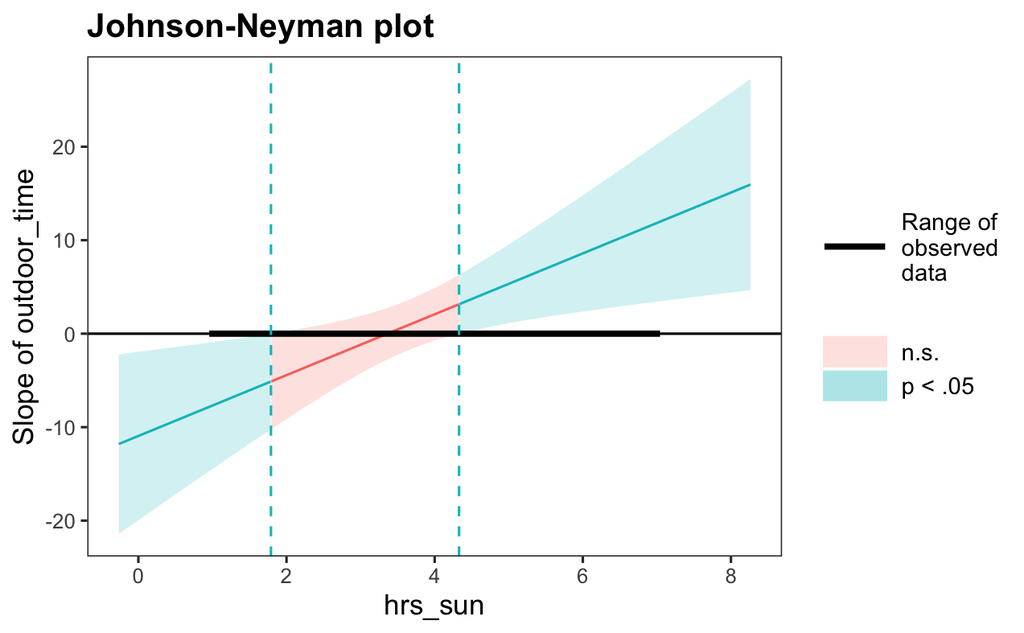

```r
m1_probe$simslopes$jnplot
```

JN plot illustrates: - At which levels of hrs_sunormance (x axis) is the slope of the line that associates `outdoor_time` with `wellbeing` significantly different from zero? - **At which levels of hrs_sunormance (x axis) do years of outdoor_timeice (outdoor_time, not on plot) significantly predict wellbeing (not on plot)?**

- when hrs_sunormance is less than like 1.8:
  - then the slope of outdoor_timeice is significantly different from zero (and negative)
- and when hrs_sunormance is above like 4.3:
  - then the slope of outdoor_timeice is significantly different from zero (and positive)

OK, put this plot on the same slide as the plot of the data at each level of `hrs_sun`, and draw lines to connect.

## Simple slopes by hand

```r
coef(m1)
```

```
         (Intercept)         outdoor_time              hrs_sun outdoor_time:hrs_sun
           87.919589           -10.943918             3.154015             3.254947
```

$$\begin{align}
\widehat{wellbeing} &= \beta_0 + (\beta_1 \cdot outdoor_time) +
(\beta_2 \cdot hrs_sun) + (\beta_3 \cdot outdoor_time \cdot hrs_sun)\\
\widehat{wellbeing} &= 87.9 + (-10.9 \cdot outdoor_time) +
(3.2 \cdot hrs_sun) + (3.3 \cdot outdoor_time \cdot hrs_sun)\\
\end{align}$$

(working-out with bad rounding on p. 31 of book)

### For hrs_suns 0 thru 7

When hrs_sun = 0:

```r
coef(m1)[['(Intercept)']]  # intercept
```

```
[1] 87.91959
```

```r
coef(m1)[['serv']]      # slope
```

```
[1] -10.94392
```

When hrs_sun = 1:

```r
coef(m1)[['(Intercept)']] + coef(m1)[['perf']]      # intercept
```

```
[1] 91.0736
```

```r
coef(m1)[['serv']] + coef(m1)[['serv:perf']]  # slope
```

```
[1] -7.688971
```

When hrs_sun = 7:

```r
coef(m1)[['(Intercept)']] + (7 * coef(m1)[['perf']]) # intercept
```

```
[1] 109.9977
```

```r
coef(m1)[['serv']] + (7 * coef(m1)[['serv:perf']])   # slope
```

```
[1] 11.84071
```

### For hrs_suns -1SD, mean, +1SD

```r
(meanperf <- mean(salary$perf))
```

```
[1] 3.8
```

```r
(lowerperf <- meanperf - sd(salary$perf))
```

```
[1] 2.536687
```

```r
(upperperf <- meanperf + sd(salary$perf))
```

```
[1] 5.063313
```

When hrs_sun is at its mean – 1 SD:

```r
coef(m1)[['(Intercept)']] + (lowerperf * coef(m1)[['perf']]) # intercept
```

```
[1] 95.92034
```

```r
coef(m1)[['serv']] + (lowerperf * coef(m1)[['serv:perf']])   # slope
```

```
[1] -2.687136
```

When hrs_sun is at its mean:

```r
coef(m1)[['(Intercept)']] + (meanperf * coef(m1)[['perf']]) # intercept
```

```
[1] 99.90485
```

```r
coef(m1)[['serv']] + (meanperf * coef(m1)[['serv:perf']])   # slope
```

```
[1] 1.42488
```

When hrs_sun is at its mean + 1 SD:

```r
coef(m1)[['(Intercept)']] + (upperperf * coef(m1)[['perf']]) # intercept
```

```
[1] 103.8894
```

```r
coef(m1)[['serv']] + (upperperf * coef(m1)[['serv:perf']])   # slope
```

```
[1] 5.536896
```

Those lines match the ones generated by `probe_interaction()`.

# Centre both predictors

```r
outdoors <- outdoors |>
  mutate(
    outdoor_time_c = scale(outdoor_time, center = TRUE, scale = FALSE),
    hrs_sun_c = scale(hrs_sun, center = TRUE, scale = FALSE),
  )

m2 <- lm(wellbeing ~ outdoor_time_c * hrs_sun_c, data = outdoors)
summary(m2)
```

```
Call:
lm(formula = wellbeing ~ outdoor_time_c * hrs_sun_c, data = outdoors)

Residuals:
    Min      1Q  Median      3Q     Max
-43.008  -9.710  -1.068   8.674  48.494

Coefficients:
                         Estimate Std. Error t value Pr(>|t|)
(Intercept)               104.848      1.757  59.686  < 2e-16 ***
outdoor_time_c              1.425      1.364   1.044  0.29890
hrs_sun_c                  14.445      1.399  10.328  < 2e-16 ***
outdoor_time_c:hrs_sun_c    3.255      1.193   2.728  0.00758 **
---
Signif. codes:  0 ‘***’ 0.001 ‘**’ 0.01 ‘*’ 0.05 ‘.’ 0.1 ‘ ’ 1

Residual standard error: 17.55 on 96 degrees of freedom
Multiple R-squared:  0.5404,    Adjusted R-squared:  0.5261
F-statistic: 37.63 on 3 and 96 DF,  p-value: 3.631e-16
```

```r
m2_probe <- probe_interaction(
  m2,
  pred = outdoor_time_c,
  modx = hrs_sun_c,
  cond.int = T,
  interval = T,
  jnplot = T
)
```

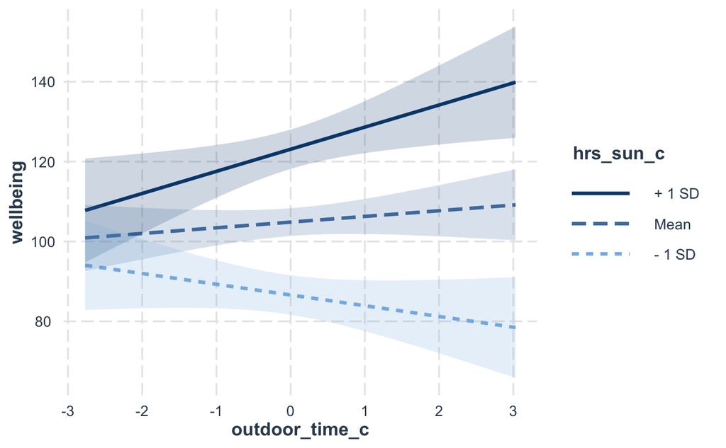

```r
m2_probe$interactplot
```

## Simple slopes sig test

Gives both a pretty-printed simple slopes analysis and the johnson-neyman plot.

```
JOHNSON-NEYMAN INTERVAL

When hrs_sun_c is OUTSIDE the interval [-2.01, 0.53], the slope of outdoor_time_c is p <
.05.

Note: The range of observed values of hrs_sun_c is [-2.80, 3.20]

SIMPLE SLOPES ANALYSIS

When hrs_sun_c = -1.263313e+00 (- 1 SD):

                                 Est.   S.E.   t val.      p
----------------------------- ------- ------ -------- ------
Slope of outdoor_time_c         -2.69   1.88    -1.43   0.16
Conditional intercept           86.60   2.49    34.73   0.00

When hrs_sun_c =  5.329071e-17 (Mean):

                                  Est.   S.E.   t val.      p
----------------------------- -------- ------ -------- ------
Slope of outdoor_time_c           1.42   1.36     1.04   0.30
Conditional intercept           104.85   1.76    59.69   0.00

When hrs_sun_c =  1.263313e+00 (+ 1 SD):

                                  Est.   S.E.   t val.      p
----------------------------- -------- ------ -------- ------
Slope of outdoor_time_c           5.54   2.18     2.54   0.01
Conditional intercept           123.10   2.49    49.45   0.00
```

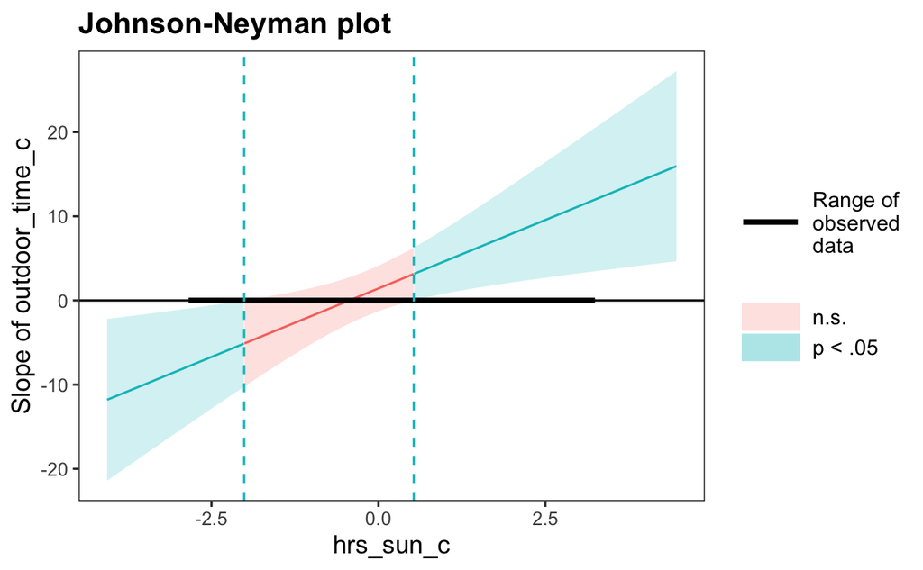

```r
m2_probe$simslopes
```

```r
m2_probe$simslopes$slopes
```

| Value of hrs_sun_c | Est. | S.E. | 2.5% | 97.5% | t val. | p |
| --- | --- | --- | --- | --- | --- | --- |
| -1.263313e+00 | -2.687136 | 1.877723 | -6.414387 | 1.040114 | -1.431061 | 0.15565998 |
| 5.329071e-17 | 1.424880 | 1.364229 | -1.283094 | 4.132854 | 1.044458 | 0.29889653 |
| 1.263313e+00 | 5.536896 | 2.177515 | 1.214564 | 9.859229 | 2.542760 | 0.01259677 |

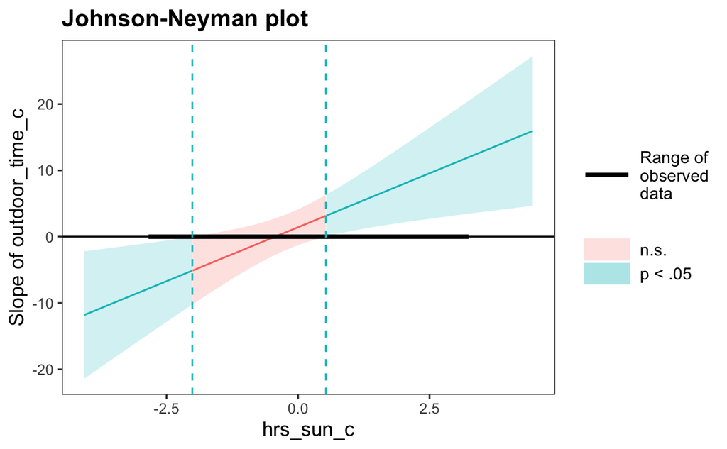

```r
m2_probe$simslopes$jnplot
```

## symmetrical probe

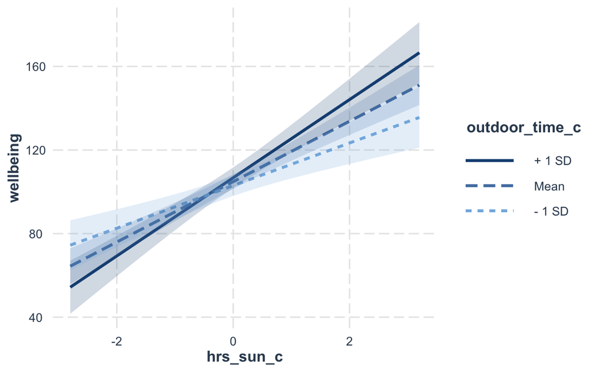

```r
probe_interaction(
  m2,
  pred = hrs_sun_c,
  modx = outdoor_time_c,
  cond.int = T,
  interval = T,
  jnplot = T
)$interactplot
```

Can flip the interpretation

# OLD Simdat to illustrate diff types of ixns

## ord / disord

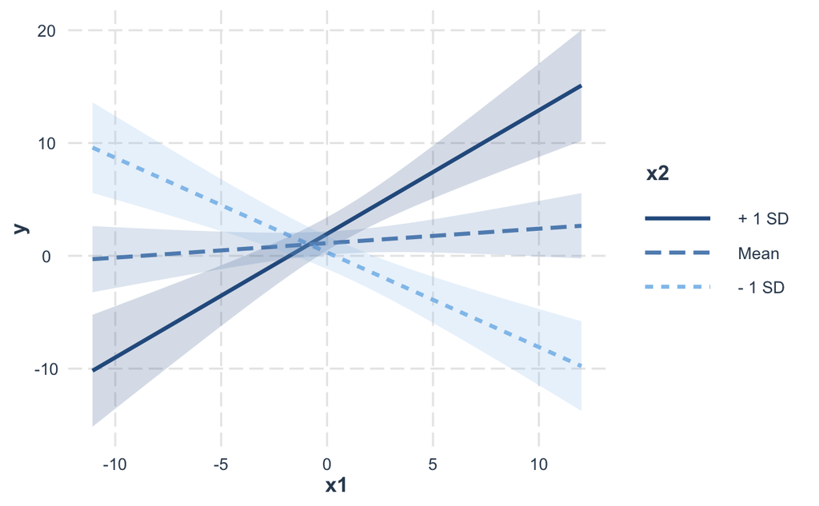

```r
sim_arguments <- list(
  formula = y ~ 1 + x1 + x2 + x1:x2,
  fixed = list(x1 = list(var_type = 'continuous', mean = 0, sd = 5),
               x2 = list(var_type = 'continuous', mean = 0, sd = 5)),
  error = list(variance = 25),
  sample_size = 100,
  reg_weights = c(1, .2, .2, .25)
)

set.seed(1)
d1 <- simulate_fixed(data = NULL, sim_arguments) |>
  simulate_error(sim_arguments) |>
  generate_response(sim_arguments)

m1 <- lm(y ~ x1 * x2, data = d1)
probe_interaction(m1, pred = x1, modx = x2, interval = T)$interactplot
```

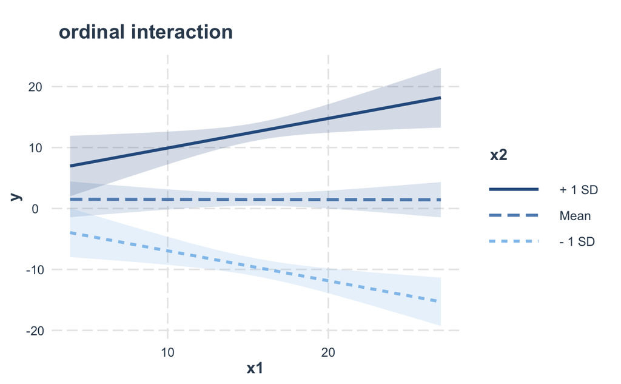

```r
sim_arguments <- list(
  formula = y ~ 1 + x1 + x2 + x1:x2,
  fixed = list(x1 = list(var_type = 'continuous', mean = 15, sd = 5),
               x2 = list(var_type = 'continuous', mean = 0, sd = 5)),
  error = list(variance = 25),
  sample_size = 100,
  reg_weights = c(1, .05, .05, .15)
)

set.seed(1)
d1 <- simulate_fixed(data = NULL, sim_arguments) |>
  simulate_error(sim_arguments) |>
  generate_response(sim_arguments)

m1 <- lm(y ~ x1 * x2, data = d1)
probe_interaction(m1, pred = x1, modx = x2, interval = T)$interactplot +
  ggtitle('ordinal interaction')
```

## not useful for seeing diff coef constellations

```r
# from simglm vignette
# https://cran.r-project.org/web/packages/simglm/vignettes/tidy_simulation.html
set.seed(321)

sim_arguments <- list(
  formula = y ~ 1 + weight + age + sex,
  fixed = list(weight = list(var_type = 'continuous', mean = 180, sd = 30),
               age = list(var_type = 'ordinal', levels = 30:60),
               sex = list(var_type = 'factor', levels = c('male', 'female'))),
  error = list(variance = 25),
  sample_size = 50,
  reg_weights = c(2, 0.3, -0.1, 0.5)
)

simulate_fixed(data = NULL, sim_arguments) |>
  simulate_error(sim_arguments) |>
  generate_response(sim_arguments) |>
  ggplot(aes(x = weight, y = y, colour = age)) +
  geom_point() +
  facet_wrap(~ sex)
```

reg weights where c(intercept, x1 slope, x2 slope, ixn slope)

synergistic: - c(1, 1, 1, 1) - c(1, -1, -1, -1)

antagonistic: - c(1, 1, 1, -1) - c(1, -1, -1, 1)

buffering - c(1, 1, -1, 1) or c(1, 1, -1, -1) - c(1, -1, 1, -1) or c(1, -1, 1, 1)

```r
sim_arguments <- list(
  formula = y ~ 1 + x1 + x2 + x1:x2,
  fixed = list(x1 = list(var_type = 'continuous', mean = 0, sd = 5),
               x2 = list(var_type = 'continuous', mean = 0, sd = 5)),
  error = list(variance = 25),
  sample_size = 100,
  reg_weights = c(1, .2, .2, 0)
)

set.seed(1)
d1 <- simulate_fixed(data = NULL, sim_arguments) |>
  simulate_error(sim_arguments) |>
  generate_response(sim_arguments)

m1 <- lm(y ~ x1 * x2, data = d1)
summary(m1)

probe_interaction(m1, pred = x1, modx = x2, interval = T)$interactplot +
  ggtitle('no ixn')
```

[output not shown]

```r
sim_arguments <- list(
  formula = y ~ 1 + x1 + x2 + x1:x2,
  fixed = list(x1 = list(var_type = 'continuous', mean = 0, sd = 5),
               x2 = list(var_type = 'continuous', mean = 0, sd = 5)),
  error = list(variance = 25),
  sample_size = 100,
  reg_weights = c(1, .2, .2, .2)
)

set.seed(1)
d1 <- simulate_fixed(data = NULL, sim_arguments) |>
  simulate_error(sim_arguments) |>
  generate_response(sim_arguments)

m1 <- lm(y ~ x1 * x2, data = d1)
summary(m1)

probe_interaction(m1, pred = x1, modx = x2, interval = T)$interactplot +
  ggtitle('synergistic pos')
```

[output not shown]

```r
sim_arguments <- list(
  formula = y ~ 1 + x1 + x2 + x1:x2,
  fixed = list(x1 = list(var_type = 'continuous', mean = 0, sd = 5),
               x2 = list(var_type = 'continuous', mean = 0, sd = 5)),
  error = list(variance = 25),
  sample_size = 100,
  reg_weights = c(1, -.2, -.2, -.2)
)

set.seed(1)
d1 <- simulate_fixed(data = NULL, sim_arguments) |>
  simulate_error(sim_arguments) |>
  generate_response(sim_arguments)

m1 <- lm(y ~ x1 * x2, data = d1)
summary(m1)

probe_interaction(m1, pred = x1, modx = x2, interval = T)$interactplot +
  ggtitle('synergistic neg')
```

[output not shown]

```r
sim_arguments <- list(
  formula = y ~ 1 + x1 + x2 + x1:x2,
  fixed = list(x1 = list(var_type = 'continuous', mean = 0, sd = 5),
               x2 = list(var_type = 'continuous', mean = 0, sd = 5)),
  error = list(variance = 25),
  sample_size = 100,
  reg_weights = c(1, .2, .2, -.2)
)

set.seed(1)
d1 <- simulate_fixed(data = NULL, sim_arguments) |>
  simulate_error(sim_arguments) |>
  generate_response(sim_arguments)

m1 <- lm(y ~ x1 * x2, data = d1)
summary(m1)

probe_interaction(m1, pred = x1, modx = x2, interval = T)$interactplot +
  ggtitle('antagonistic (mostly pos)')
```

[output not shown]

```r
sim_arguments <- list(
  formula = y ~ 1 + x1 + x2 + x1:x2,
  fixed = list(x1 = list(var_type = 'continuous', mean = 0, sd = 5),
               x2 = list(var_type = 'continuous', mean = 0, sd = 5)),
  error = list(variance = 25),
  sample_size = 100,
  reg_weights = c(1, -.2, -.2, .2)
)

set.seed(1)
d1 <- simulate_fixed(data = NULL, sim_arguments) |>
  simulate_error(sim_arguments) |>
  generate_response(sim_arguments)

m1 <- lm(y ~ x1 * x2, data = d1)
summary(m1)

probe_interaction(m1, pred = x1, modx = x2, interval = T)$interactplot +
  ggtitle('antagonistic (mostly neg)')
```

[output not shown]

```r
sim_arguments <- list(
  formula = y ~ 1 + x1 + x2 + x1:x2,
  fixed = list(x1 = list(var_type = 'continuous', mean = 0, sd = 5),
               x2 = list(var_type = 'continuous', mean = 0, sd = 5)),
  error = list(variance = 25),
  sample_size = 100,
  reg_weights = c(1, -.2, .2, .2)
)

set.seed(1)
d1 <- simulate_fixed(data = NULL, sim_arguments) |>
  simulate_error(sim_arguments) |>
  generate_response(sim_arguments)

m1 <- lm(y ~ x1 * x2, data = d1)
summary(m1)

probe_interaction(m1, pred = x1, modx = x2, interval = T)$interactplot +
  ggtitle('buffering')
```

[output not shown]

So that means that this kind of thing is restricted to looking at hte coefs and interpreting htem, not actuallky looking at the data.

Whereas the ordinal vs. disordinal thing IS for looking at the plots, not hte coefs. OK. That’s useful!

# Appendix